# Reexplorando PROPERATI

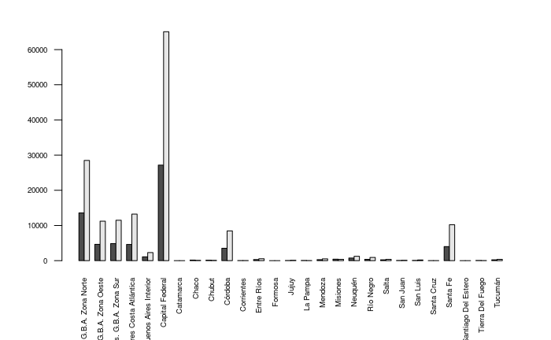

```r
uni.prov <- unique(datos1a$l2)
#ventas <- datos2$l2[datos2$operation_type == "Venta"]
#alquileres <- datos2$l2[datos2$operation_type == "Alquiler"]
num.ventas <- datos2$operation_type == "Venta"
#num.alquileres <-
#mosaicplot(datos2$operation_type~datos2$l2)

barplot(t(tabla.prov), las=2, beside=T, cex.names = 0.6, cex.axis = 0.6)
```

```r
venta.mask <- datos2$operation_type == "Venta"
alquiler.mask <- datos2$operation_type == "Alquiler"

tabla.prov.venta <- table(datos2$l2[venta.mask], datos2$price[venta.mask])#, proporcion)
tabla.prov.alquiler <- table(datos2$l2[alquiler.mask], datos2$price[alquiler.mask])
tabla.prov
```

```
                               Alquiler Venta
  Bs.As. G.B.A. Zona Norte        13577 28488
  Bs.As. G.B.A. Zona Oeste         4639 11223
  Bs.As. G.B.A. Zona Sur           4853 11485
  Buenos Aires Costa Atlántica     4604 13226
  Buenos Aires Interior            1097  2296
  Capital Federal                 27165 65074
  Catamarca                           0     3
  Chaco                             167    85
  Chubut                            133    88
  Córdoba                          3521  8461
  Corrientes                         33    37
  Entre Ríos                        309   541
  Formosa                             0     2
  Jujuy                              47   103
  La Pampa                           58    24
  Mendoza                           285   508
  Misiones                          417   379
  Neuquén                           754  1246
  Río Negro                         374   917
  Salta                             241   379
  San Juan                           54   102
  San Luis                           74   195
  Santa Cruz                          9    14
  Santa Fe                         4001 10203
  Santiago Del Estero                 0     3
  Tierra Del Fuego                   58    35
  Tucumán                           236   374
```

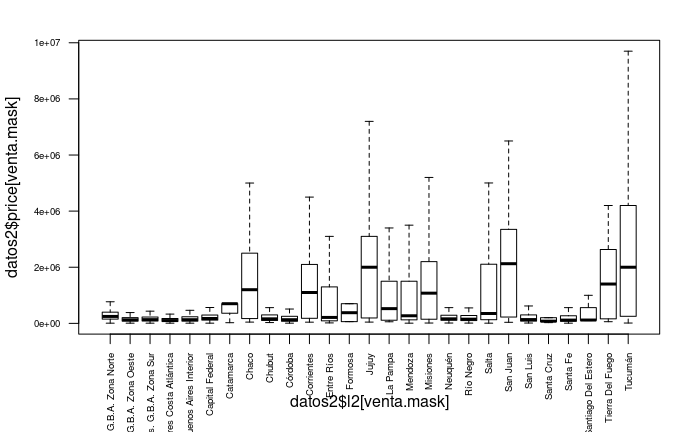

```r
uni.prov <- unique(datos1a$l2)
#ventas <- datos2$l2[datos2$operation_type == "Venta"]
#alquileres <- datos2$l2[datos2$operation_type == "Alquiler"]
precios.venta <- datos2$price[venta.mask]
precios.alquiler <- datos2$price[alquiler.mask]

#num.alquileres <-
#mosaicplot(datos2$operation_type~datos2$l2)

boxplot(datos2$price[venta.mask] ~ datos2$l2[venta.mask], las=2, beside=T, cex.names = 0.6, cex.axis = 0.6,outline=F)
```

```r
boxplot(datos2$price[alquiler.mask] ~ datos2$l2[alquiler.mask], las=2, beside=T, cex.names = 0.6, cex.axis = 0.6,outline=F, c='green')
abline(y=mean(precios.venta))
```

```
"y" is not a graphical parameter
```

```
"y" is not a graphical parameter
```

[figure not shown]

```r
abline(y=2000)
```

- ¿Qué diferencia existe en el tipo de operación (Venta o Alquiler) entre Catamarca y La Rioja? ¿Y entre Chaco y Santa Cruz?

```r
tabla.prov[[1,]]
```

```
Error in tabla.prov[[1, ]] : subscript out of bounds
```

- ¿Cómo describiría la relación entre la variable `l2` (región) y `l3` (barrio)? ¿Están igual de particionadas todas las regiones? *Construya una lista con tantos elementos cómo regiones (categorías de `l2`) y en cada elemento incluye las subregiones asociadas (categorías de `l3`). Construya un vector representando la cantidad de subregiones para cada región y resuma este vector.*

[figure not shown]

```r
regiones <- datos2$l2
subregiones <- datos2$l3

regiones.unicas <- unique(regiones)

por.region <- vector("list", length(regiones.unicas))
num.subregiones <- vector("list", length(regiones.unicas))

i <- 1
for(region in regiones.unicas){
  por.region[[i]] <- unique(subregiones[regiones==region])
  num.subregiones[[i]] <- length(por.region[[i]])
  i <- i + 1
}

# Las ordeno
num.subregiones <- num.subregiones[order(unlist(num.subregiones))]
regiones.unicas <- regiones.unicas[order(unlist(num.subregiones))]

df <- data.frame(unlist(num.subregiones))
row.names(df) <- regiones.unicas
#num.subregiones
#por.region

barplot(t(as.matrix(df)), beside=T, las=2, cex.names = 0.6, cex.axis = 0.6, c='limegreen')
```

```r
as.matrix(df)
```

[output not shown]

- Caracterice el *fondo* de las propiedades (superficie total - superficie cubierta) para distintas regiones del país. ¿En qué lugar los *fondos* son más grandes? ¿Cambia según el tipo de propiedad?